# Forecasting Methods Project

### Trend in different Continents

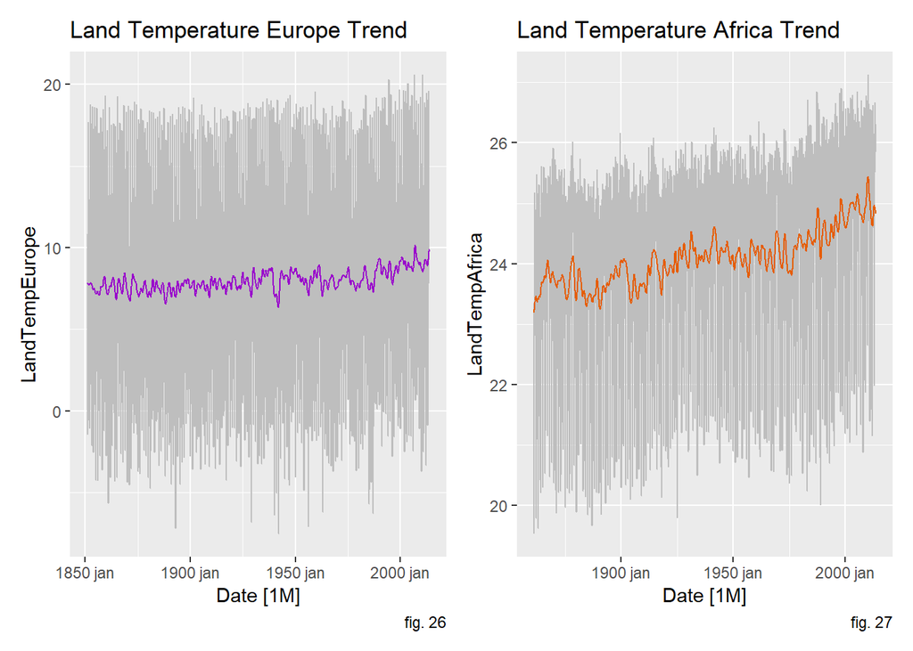

```r
#----------------------------------------------------------------

GlobalCountryTemp %>%
  filter(year(Date)> 1850) %>%
  filter (Country == 'Europe') %>%
  select(LandAvgTemp) %>%
  as_tibble() %>%
  group_by(Date) %>%
  summarise_at(vars(LandAvgTemp), list(LandTempEurope = mean)) %>%
  as_tsibble() %>%
  fill(LandTempEurope, .direction = 'down') -> tempEurope

decEurope <- tempEurope %>%
  model(stl = STL(LandTempEurope))

#components(decEurope)

Fig26 <- tempEurope %>%
  autoplot(LandTempEurope, color = 'gray') +
  autolayer(components(decEurope), trend, color = '#9900cc') +
  ggtitle('Land Temperature Europe Trend') +
  labs(caption = "fig. 26")

#----------------------------------------------------------------

GlobalCountryTemp %>%
  filter(year(Date)> 1860) %>%
  filter (Country == 'Africa') %>%
  select(LandAvgTemp) %>%
  as_tibble() %>%
  group_by(Date) %>%
  summarise_at(vars(LandAvgTemp), list(LandTempAfrica = mean)) %>%
  as_tsibble() %>%
  fill(LandTempAfrica, .direction = 'down') -> tempAfrica

decAfrica <- tempAfrica %>%
  model(stl = STL(LandTempAfrica))

#components(decAfrica)

Fig27 <- tempAfrica %>%
  autoplot(LandTempAfrica, color = 'gray') +
  autolayer(components(decAfrica), trend, color = '#e65c00') +
  ggtitle('Land Temperature Africa Trend') +
  labs(caption = "fig. 27")

#----------------------------------------------------------------

GlobalCountryTemp %>%
  filter(year(Date)> 1850) %>%
  filter (Country == 'Asia') %>%
  select(LandAvgTemp) %>%
  as_tibble() %>%
  group_by(Date) %>%
  summarise_at(vars(LandAvgTemp), list(LandTempAsia = mean)) %>%
  as_tsibble() %>%
  fill(LandTempAsia, .direction = 'down') -> tempAsia

decAsia <- tempAsia %>%
  model(stl = STL(LandTempAsia))

#components(decAsia)

Fig28 <- tempAsia %>%
  autoplot(LandTempAsia, color = 'gray') +
  autolayer(components(decAsia), trend, color = '#ff4d94') +
  ggtitle('Land Temperature Asia Trend') +
  labs(caption = "fig. 28")

#----------------------------------------------------------------

GlobalCountryTemp %>%
  filter(year(Date)> 1850) %>%
  filter (Country == 'South America') %>%
  select(LandAvgTemp) %>%
  as_tibble() %>%
  group_by(Date) %>%
  summarise_at(vars(LandAvgTemp), list(LandTempSouthAmerica = mean)) %>%
  as_tsibble() %>%
  fill(LandTempSouthAmerica, .direction = 'down') -> tempSouthAmerica

decSouthAmerica <- tempSouthAmerica %>%
  model(stl = STL(LandTempSouthAmerica))

#components(decSouthAmerica)

Fig29 <- tempSouthAmerica %>%
  autoplot(LandTempSouthAmerica, color = 'gray') +
  autolayer(components(decSouthAmerica), trend, color = '#008040') +
  ggtitle('Land Temperature South America Trend') +
  labs(caption = "fig. 29")

#----------------------------------------------------------------

GlobalCountryTemp %>%
  filter(year(Date)> 1850) %>%
  filter (Country == 'North America') %>%
  select(LandAvgTemp) %>%
  as_tibble() %>%
  group_by(Date) %>%
  summarise_at(vars(LandAvgTemp), list(LandTempNorthAmerica = mean)) %>%
  as_tsibble() %>%
  fill(LandTempNorthAmerica, .direction = 'down') -> tempNorthAmerica

decNorthAmerica <- tempNorthAmerica %>%
  model(stl = STL(LandTempNorthAmerica))

#components(decNorthAmerica)

Fig30 <- tempNorthAmerica %>%
  autoplot(LandTempNorthAmerica, color = 'gray') +
  autolayer(components(decNorthAmerica), trend, color = '#009999') +
  ggtitle('Land Temperature North America Trend') +
  labs(caption = "fig. 30")

#----------------------------------------------------------------

GlobalCountryTemp %>%
  filter(year(Date)> 1850) %>%
  filter (Country == 'Oceania') %>%
  select(LandAvgTemp) %>%
  as_tibble() %>%
  group_by(Date) %>%
  summarise_at(vars(LandAvgTemp), list(LandTempOceania = mean)) %>%
  as_tsibble() %>%
  fill(LandTempOceania, .direction = 'down') -> tempOceania

decOceania <- tempOceania %>%
  model(stl = STL(LandTempOceania))

#components(decOceania)

Fig31 <- tempOceania %>%
  autoplot(LandTempOceania, color = 'gray') +
  autolayer(components(decOceania), trend, color = '#99004d') +
  ggtitle('Land Temperature Oceania Trend') +
  labs(caption = "fig. 31")
Fig26 + Fig27
```

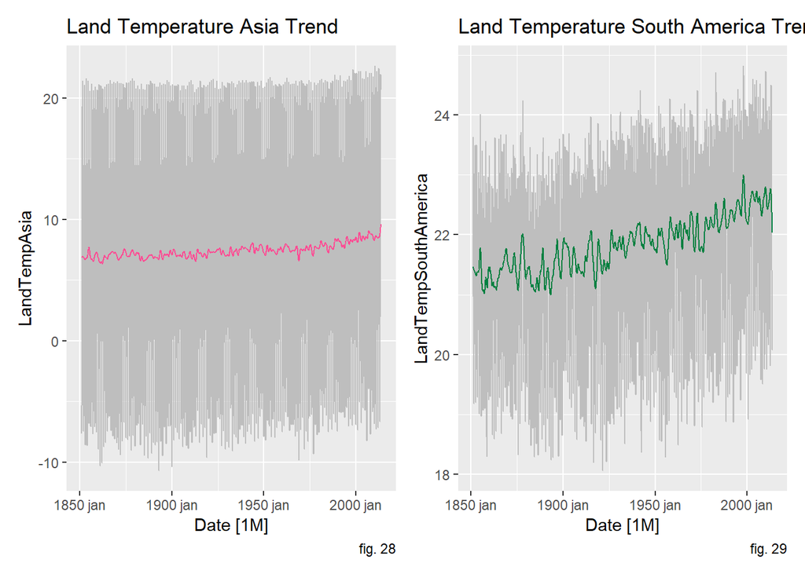

```r
Fig28 + Fig29
```

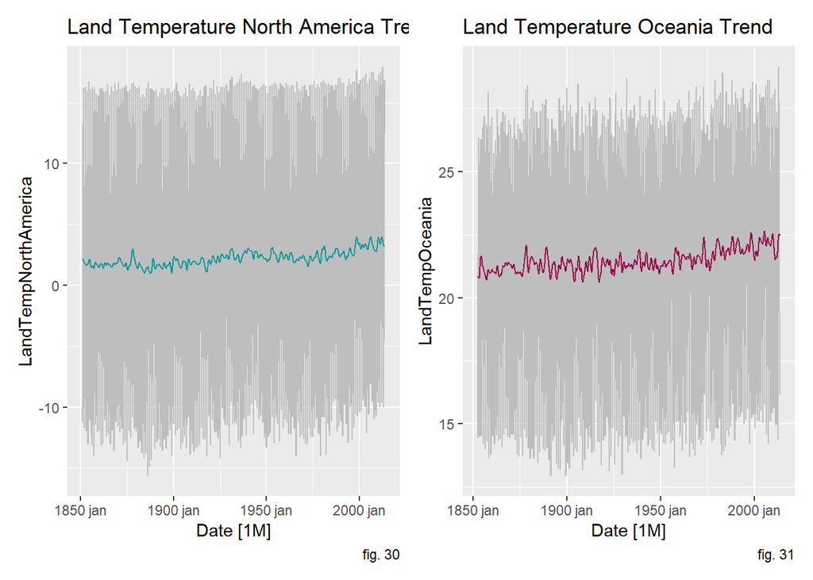

```r
Fig30 + Fig31
```

By analysing the trends on the different continents, we can draw some conclusions:

It is important to make the distinction, that the trend over time is ranging from very different values from continent to continent. While in North America the temperatures are much colder in general, in Europe and Asia they are slight more moderate. In Oceania the temperatures are hotter, ranging always above 20Cº, but in Africa and South America the temperatures are alarmingly higher, especially in Africa where temperatures start at about 23ºC in 1860, and have already over-passed the 25ºC.

### Trend and Seasonal Strenght in different Countries and Continents

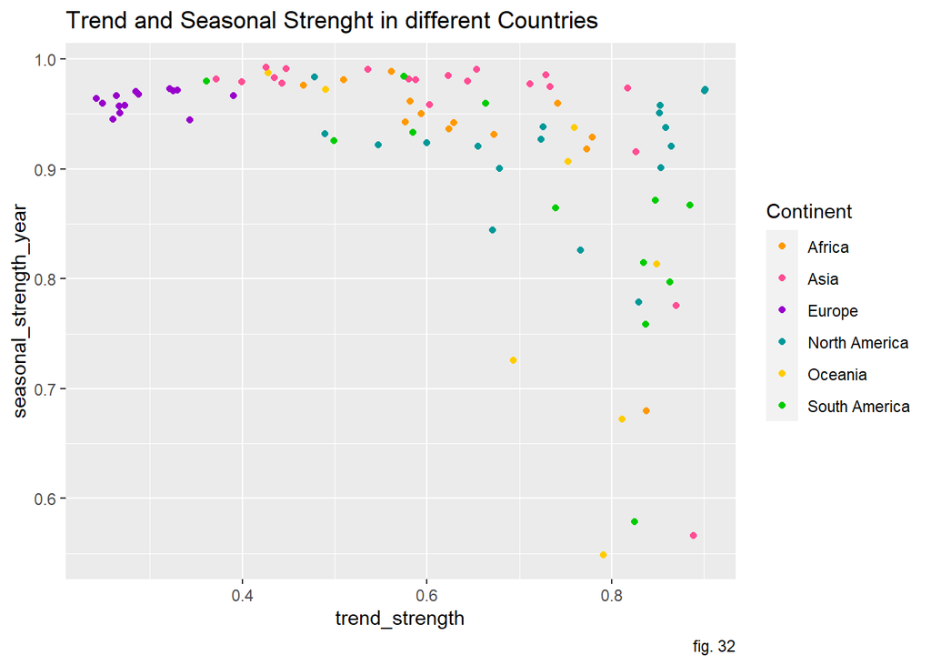

```r
GlobalCountryTemp %>%
  fill(LandAvgTemp, .direction = "down") %>%
  features(LandAvgTemp, feat_stl) %>%
  drop_na(trend_strength, seasonal_strength_year) %>%
  mutate(Continent = case_when(
    Country %in% europe  ~ "Europe" ,
    Country %in% africa  ~ "Africa" ,
    Country %in% asia  ~ "Asia" ,
    Country %in% north_america  ~ "North America",
    Country %in% south_america  ~ "South America",
    Country %in% oceania  ~ "Oceania"
  )
) %>%
  drop_na(Continent) %>%
  ggplot(aes(x = trend_strength, y = seasonal_strength_year, colour = Continent)) +
  scale_color_manual(values=c('#ff9900', '#ff4d94', '#9900cc', '#009999', '#ffcc00', '#00cc00')) +
  geom_point() +
  labs(title= 'Trend and Seasonal Strenght in different Countries', caption = "fig. 32")
```

In the scatter plot above, we can evaluate the strength of the trends and seasonal patterns on different countries, grouped by continent.

In all countries in the graph, the seasonal patterns are clearly strong (the majority with a seasonal strength higher than 0.7).

In Europe, we can see countries are in a cluster with a very high seasonal strength (temperature differences by month are more pronounced) and lower trend strength (it is not going on an upward trend as much).

In Asia the seasonal strength is very high in almost all plotted countries (above 0.85). Meaning the differences in temperatures in distinct seasons are very significant (colder winters and very hot summers/spring).

In North America, the trend is very strong in most of the countries, meaning temperatures are rising quite fast and significantly.

### Subseries of Land and Ocean Global Temperature

Moreover, on the next plot we can see that on average both the global land temperature and the global land and ocean temperature are much higher in summer months, compared to the rest, and much lower in January, February, and December. Interestingly in July and August the trend is going down. So in previous years, temperatures were higher in these months, compared to recent years.

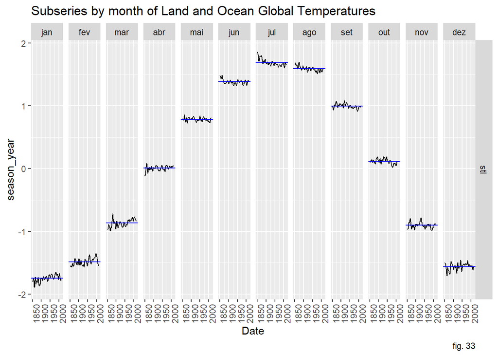

```r
components(dec) %>% gg_subseries(season_year) +
  labs(title = 'Subseries by month of Land and Ocean Global Temperatures', caption = "fig. 33")
```

## 4. The forecaster’s toolbox

In the previous chapters we have already prepared and visualized our data in order to gain a good understanding of our data. Now, we will use some benchmark forecasting methods to forecast our time series. Moreover, methods for assessing forecast accuracy will be applied.

### Specifying a model

Looking at our data allows us to identify common patterns, and subsequently specify an appropriate model. We have seen in the previous chapters that our time series for Land Average Temperature and Land & Ocean Average temperature reveal a seasonal and a trend pattern. Now, we will check which type of forecasting method is appropriate for this type of time series.

There are several simple forecasting methods. The “Average method” and the “Naïve method” are suitable for time series without any seasonality or trend pattern. Therefore, we won’t use these methods for our time series.

The “Seasonal naïve method” is appropriate for data with seasonality and the “Drift Method” for data with a trend pattern. For that reason, we will know apply these forecasting methods to our data and visualize the results.

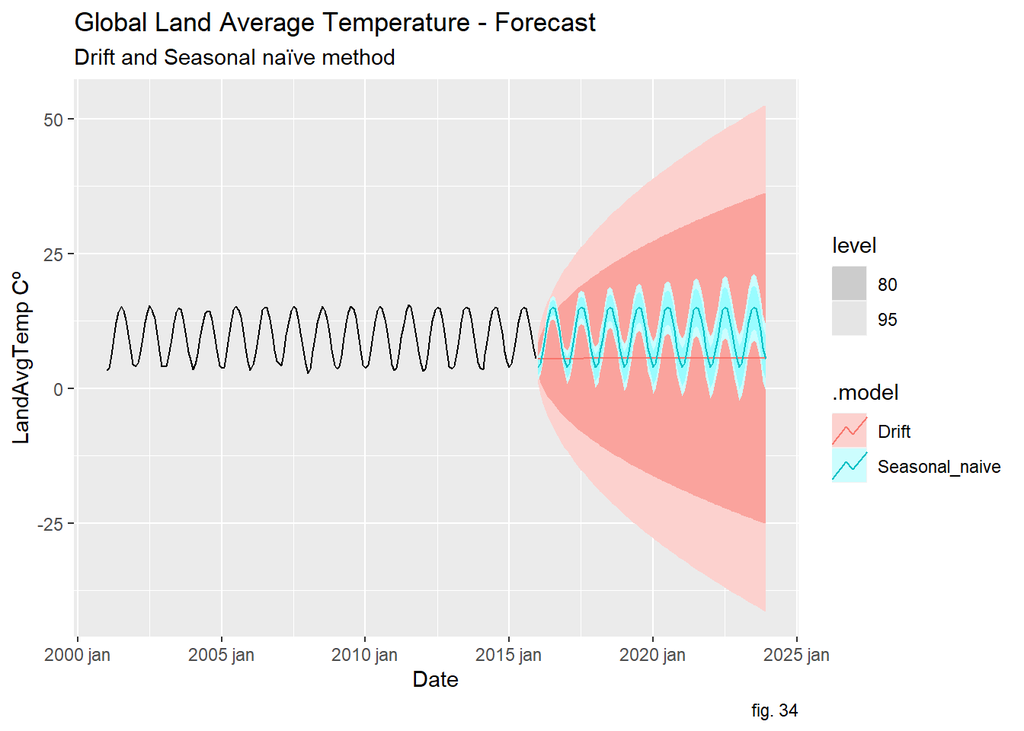

```r
GlobalCountryTemp %>%
  filter(Country=="Global") %>%
  fill(LandAvgTemp, .direction = "down") %>%
  model(Seasonal_naive = SNAIVE(LandAvgTemp),
        Drift = RW(LandAvgTemp ~ drift())
        ) %>% forecast(h = "8 years") %>%
  autoplot((filter(GlobalCountryTemp, year(Date) > 2000))) +
  labs(title = "Global Land Average Temperature - Forecast",
       subtitle = "Drift and Seasonal naïve method",
       y="LandAvgTemp Cº",
       caption = "fig. 34")
```

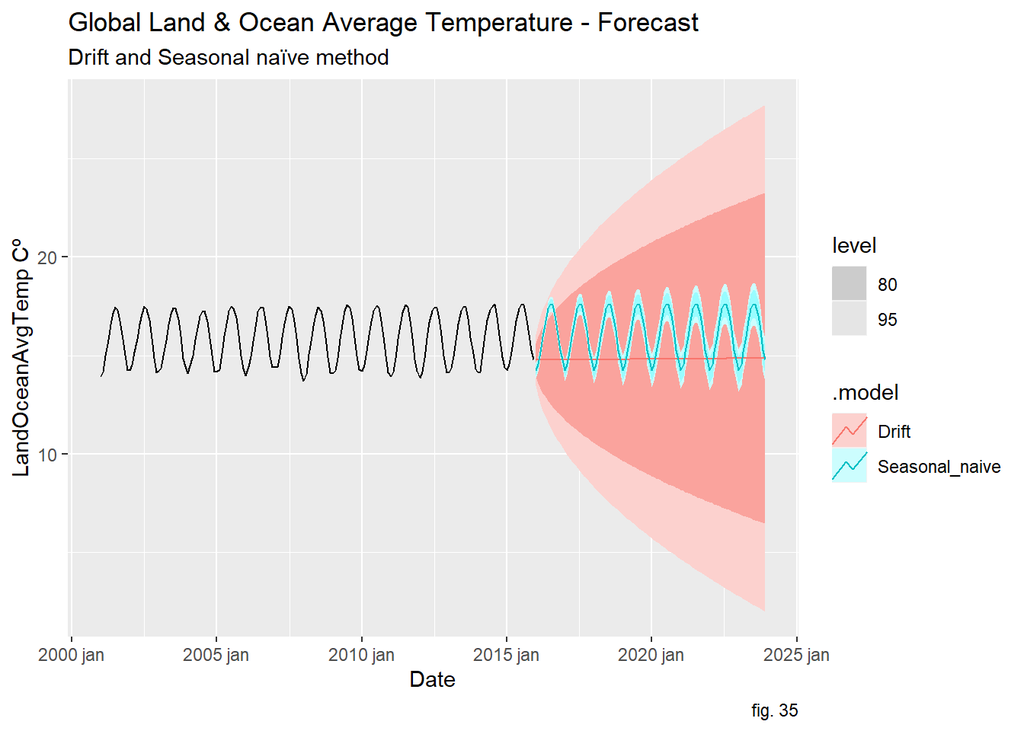

```r
GlobalCountryTemp %>%
  filter(Country=="Global") %>%
  fill(LandOceanAvgTemp, .direction = "down") %>%
  model(Seasonal_naive = SNAIVE(LandOceanAvgTemp),
        Drift = RW(LandOceanAvgTemp ~ drift())
        ) %>% forecast(h = "8 years") %>%
  autoplot(filter(GlobalCountryTemp, year(Date) > 2000)) +
  labs(title = "Global Land & Ocean Average Temperature - Forecast",
       subtitle = "Drift and Seasonal naïve method",
       y="LandOceanAvgTemp Cº",
       caption = "fig. 35")
```

The figures above show the forecasts for the next 8 years (from 2016 onward) estimated by the “Seasonal naïve method” and the “Drift Method” for the times Series “Global Land Average temperature” and “Global Land & Ocean Temperature”, respectively. It can be seen that the area for the prediction intervals is high (espicially for the “Drift method”), which means that there is a high uncertainty in the forecasts. One reason for this may be that one method is suitable for data with seasonality and the other method for data with trend. But in fact our time series has both seasonality and trend.

Let’s try to apply the “Drift Method” on the seasonal adjusted data, so that we capture both components in our forecast: Seasonality and Trend.

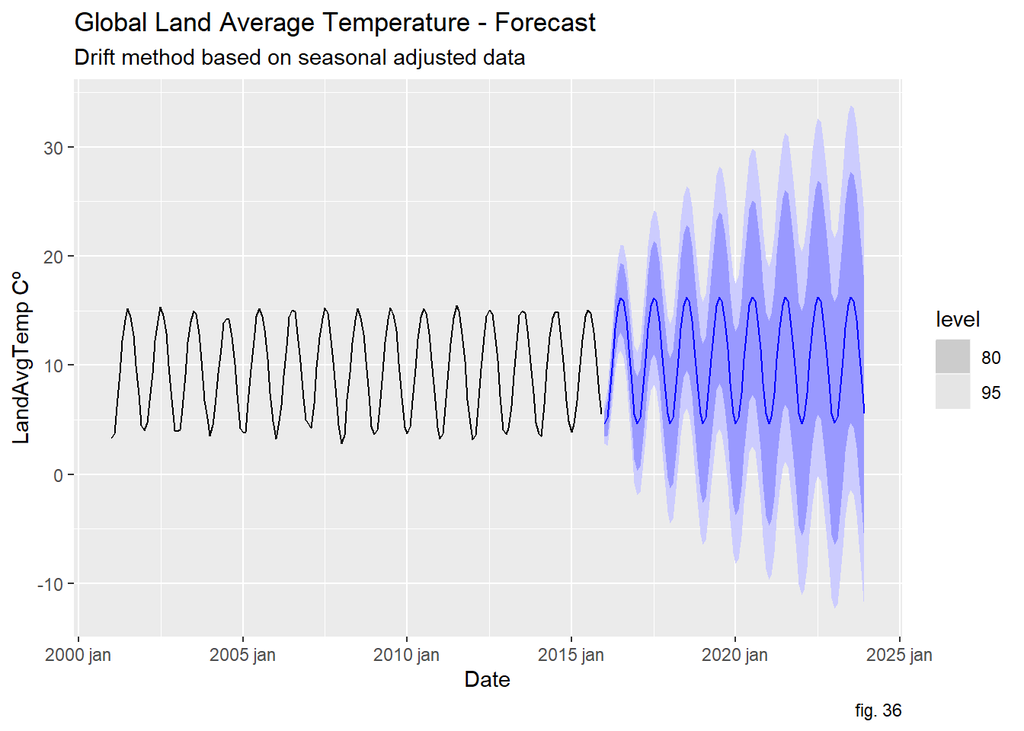

```r
GlobalCountryTemp %>%
  filter(Country=="Global") %>%
  fill(LandAvgTemp, .direction = "down") %>%
  model(stlf = decomposition_model(
    STL(LandAvgTemp ~ trend(window = 7), robust = TRUE),
        Drift = RW(season_adjust ~ drift())
    )) %>%
  forecast(h = "8 years") %>%
  autoplot(filter(GlobalCountryTemp, year(Date) > 2000)) +
  labs(title = "Global Land Average Temperature - Forecast",
       subtitle = "Drift method based on seasonal adjusted data",
       y="LandAvgTemp Cº",
       caption = "fig. 36")
```

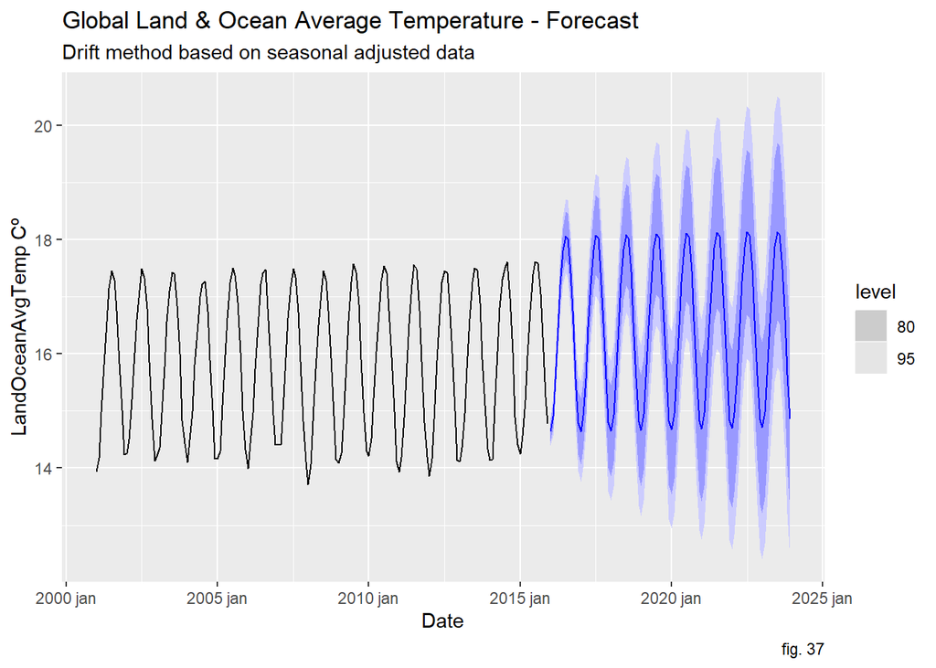

```r
GlobalCountryTemp %>%
  filter(Country=="Global") %>%
  fill(LandOceanAvgTemp, .direction = "down") %>%
  filter(!is.na(LandOceanAvgTemp)) %>%
  model(stlf = decomposition_model(
    STL(LandOceanAvgTemp ~ trend(window = 7), robust = TRUE),
        Drift = RW(season_adjust ~ drift())
    )) %>%
  forecast(h = "8 years") %>%
  autoplot(filter(GlobalCountryTemp, year(Date) > 2000)) +
  labs(title = "Global Land & Ocean Average Temperature - Forecast",
       subtitle = "Drift method based on seasonal adjusted data",
       y="LandOceanAvgTemp Cº",
       caption = "fig. 37")
```

The figures above show the forecasts for the next 8 years (from 2016 onward) estimated by the “Drift Method” based on the seasonal adjusted data (based on STL Decomposition) for the times Series “Global Land Average temperature” and “Global Land & Ocean Temperature”, respectively. The prediction intervals are still big, especially for the forecast of the “Global Land Average temperature”. When we compare the prediction interval to those of the “Seasonal naïve method” in the figures before they seem to be even bigger.

In the following chapter we will calculate the forecasting accuracy and check if our intuition about the best method is true.

### Accuracy & performance evaluation

In this chapter we will divide our data in training and test sets to evaluate the forecasting accuracy. For this purpose the time series cross-validation is used. In this procedure, there are a number of test sets, each consisting of a single observation. The corresponding training set consists only of observations that occurred before the observation that forms the test set. By averaging over the test series the forecasting accuracy is calculated.

#### Global land average temperature forecast

```r
GlobalCountryTemp %>%
  filter(Country=="Global") %>%
  filter(year(Date)>=1990) %>%
  fill(LandAvgTemp, .direction = "down") %>%
  filter(!is.na(LandAvgTemp)) %>%
  stretch_tsibble(.init = 3, .step = 1) %>%
  model(Seasonal_naive = SNAIVE(LandAvgTemp),
        Drift = RW(LandAvgTemp ~ drift())
        ) %>% forecast(h = "8 years") %>%
  accuracy(GlobalCountryTemp)
```

```
## # A tibble: 2 x 11
##   .model    Country .type     ME   RMSE   MAE     MPE   MAPE   MASE  RMSSE  ACF1
##   <chr>     <chr>   <chr>  <dbl>  <dbl> <dbl>   <dbl>  <dbl>  <dbl>  <dbl> <dbl>
## 1 Drift     Global  Test  -5.77  19.9   9.53  -109.   140.   14.0   17.9   0.983
## 2 Seasonal~ Global  Test   0.113  0.455 0.355    1.06   5.30  0.521  0.409 0.319
```

```r
GlobalCountryTemp %>%
  filter(Country=="Global") %>%
  filter(year(Date)>=1990) %>%
  fill(LandAvgTemp, .direction = "down") %>%
  filter(!is.na(LandAvgTemp)) %>%
  stretch_tsibble(.init = 3, .step = 1) %>%
  model(stlf = decomposition_model(
    STL(LandAvgTemp ~ trend(window = 7), robust = TRUE),
        Drift = RW(season_adjust ~ drift())
    )) %>% forecast(h = "8 years") %>%
  accuracy(GlobalCountryTemp)
```

```
## # A tibble: 1 x 11
##   .model Country .type    ME  RMSE   MAE   MPE  MAPE  MASE RMSSE  ACF1
##   <chr>  <chr>   <chr> <dbl> <dbl> <dbl> <dbl> <dbl> <dbl> <dbl> <dbl>
## 1 stlf   Global  Test  -3.35  18.2  3.89 -51.0  57.5  5.71  16.4 0.988
```

In the figures above we can see the accuracy of the three different models for the Average global Land Temperature. The RMSE is a good way to choose the best forecasting model. The RMSE of the “Seasonal naïve method” is the smallest, followed by the “Drift Method” on seasonal adjusted data and then the normal “Drift method”.

#### Global land and ocean average temperature forecast

```r
GlobalCountryTemp %>%
  filter(Country=="Global") %>%
  filter(year(Date)>=1990) %>%
  fill(LandOceanAvgTemp, .direction = "down") %>%
  filter(!is.na(LandOceanAvgTemp)) %>%
  stretch_tsibble(.init = 3, .step = 1) %>%
  model(Seasonal_naive = SNAIVE(LandOceanAvgTemp),
        Drift = RW(LandOceanAvgTemp ~ drift())
        ) %>% forecast(h = "8 years") %>%
  accuracy(GlobalCountryTemp)
```

```
## # A tibble: 2 x 11
##   .model       Country .type      ME  RMSE   MAE     MPE  MAPE  MASE RMSSE  ACF1
##   <chr>        <chr>   <chr>   <dbl> <dbl> <dbl>   <dbl> <dbl> <dbl> <dbl> <dbl>
## 1 Drift        Global  Test  -1.66   5.88  2.79  -11.2   18.0  18.4  30.1  0.983
## 2 Seasonal_na~ Global  Test   0.0701 0.197 0.156   0.436  1.00  1.03  1.01 0.605
```

```r
GlobalCountryTemp %>%
  filter(Country=="Global") %>%
  filter(year(Date)>=1990) %>%
  fill(LandOceanAvgTemp, .direction = "down") %>%
  filter(!is.na(LandOceanAvgTemp)) %>%
  stretch_tsibble(.init = 3, .step = 1) %>%
  model(stlf = decomposition_model(
    STL(LandOceanAvgTemp ~ trend(window = 7), robust = TRUE),
        Drift = RW(season_adjust ~ drift())
    )) %>% forecast(h = "8 years") %>%
  accuracy(GlobalCountryTemp)
```

```
## # A tibble: 1 x 11
##   .model Country .type     ME  RMSE   MAE   MPE  MAPE  MASE RMSSE  ACF1
##   <chr>  <chr>   <chr>  <dbl> <dbl> <dbl> <dbl> <dbl> <dbl> <dbl> <dbl>
## 1 stlf   Global  Test  -0.952  5.40  1.20 -6.20  7.74  7.86  27.6 0.988
```

In the figures above we can see the accuracy of the three different models for the Average global Land & Ocean Temperature. By evaluating the RMSE we can again see that the forecasting accuracy of the “Seasonal naïve method” is the best, followed by the “Drift Method” on seasonal adjusted data and then the normal “Drift method”.

#### Checking Residuals of selected method

Based on our previous analysis, we can conclude that the “Seasonal naïve method” is the most appropriate method for our time series. Let’s have a look at the residuals of this method:

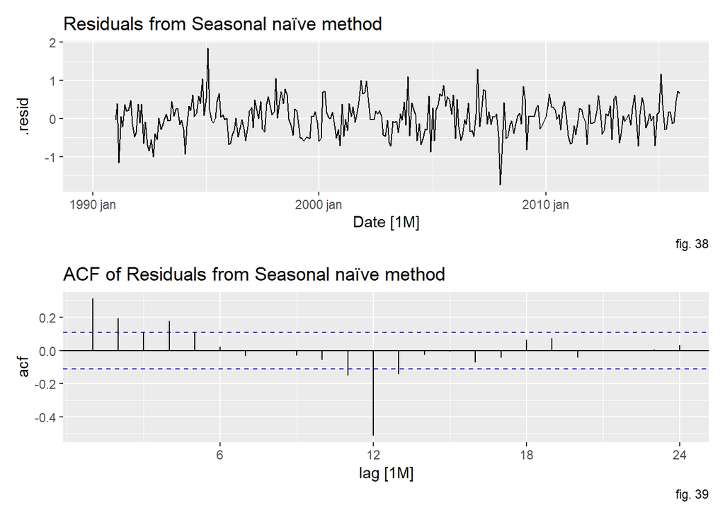

```r
Fig38<- GlobalCountryTemp %>%
  filter(Country=="Global") %>%
  filter(year(Date)>=1990) %>%
  fill(LandAvgTemp, .direction = "down") %>%
  model(Seasonal_naive = SNAIVE(LandAvgTemp)) %>%
  augment() %>%
  autoplot(.resid) + labs(title = "Residuals from Seasonal naïve method", caption = "fig. 38")

Fig39<- GlobalCountryTemp %>%
  filter(Country=="Global") %>%
  filter(year(Date)>=1990) %>%
  fill(LandAvgTemp, .direction = "down") %>%
  model(Seasonal_naive = SNAIVE(LandAvgTemp)) %>%
  augment() %>%
  ACF(.resid) %>%
  autoplot() + labs(title = "ACF of Residuals from Seasonal naïve method", caption = "fig. 39")

Fig38 / Fig39
```

We have limited our time series to data from 1990 onwards, as we do not need data from 1850 onwards. In the two figures above we can see the residuals from the “Seasonal naïve method” and the ACF of the residuals from the “Seasonal naïve method”. The ACF value is for some lags very low, but we can also see that there are several outliers. Therefore, we can’t say that the residuals of our selected method looks like white noise. This means that none of the Benchmark method is optimal for our time series. However, the “Seasonal naïve method” seems to perform good with regard to the forecasting accuracy.

## 5. Exponential Smoothing

The second to last topic in this report will focus entirely in applying Exponential Smoothing methods to the given time-series. Firstly, ETS forecasting will be applied to the global average temperatures, as well as land average temperatures for each continent. Secondly, an assessment of the forecast accuracy will be analyzed.

### Global Land Average Temperature

Due to the strong presence of seasonality in our data, the most appropriate Exponential Smoothing methods would most likely be the ones with a seasonal component, such as Holt-Winters Additive Method or Holt-Winters Multiplicative Method. Besides that, a more simpel ETS Method without a trend component could also be considered.Therefore, in this first step, these three exponential smoothing methods are applied.

```r
global_temp <-
  GlobalCountryTemp %>%
  filter(Country == "Global") %>%
  filter(year(Date)>=1990)

fit_global_land <- global_temp %>%
  model(
    ANA_Land = ETS(LandAvgTemp ~ error("A") + trend("N") + season("A")),
    AAA_Land = ETS(LandAvgTemp ~ error("A") + trend("A") + season("A")),
    MAM_Land = ETS(LandAvgTemp ~ error("M") + trend("A") + season("M"))
    )

fit_ANA <- global_temp %>% model(ANA = ETS(LandAvgTemp ~ error("A") + trend("N") + season("A")))

report(fit_global_land)
```

```
## # A tibble: 3 x 10
##   Country .model    sigma2 log_lik   AIC  AICc   BIC    MSE   AMSE    MAE
##   <chr>   <chr>      <dbl>   <dbl> <dbl> <dbl> <dbl>  <dbl>  <dbl>  <dbl>
## 1 Global  ANA_Land 0.0900    -513. 1056. 1058. 1112. 0.0860 0.0947 0.231
## 2 Global  AAA_Land 0.0909    -514. 1061. 1063. 1125. 0.0862 0.0947 0.231
## 3 Global  MAM_Land 0.00340   -663. 1360. 1362. 1423. 0.119  0.135  0.0381
```

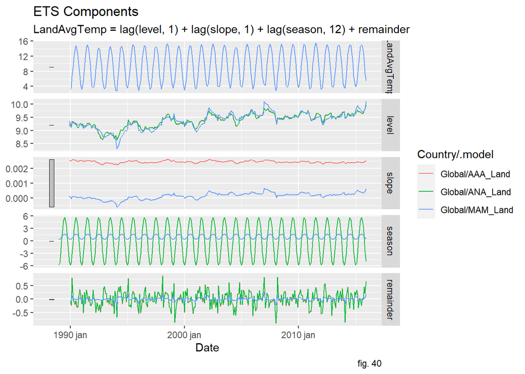

```r
fit_global_land %>%
  components() %>%
  autoplot() + labs(title = "ETS Components", caption = "fig. 40")
```

It seems that when the time series is limited from 1990 onward, the ideal exponential smoothing method is the one which does not include any trend (slope). Besides that, the ones that do include a trend (Holt-Winters Additive and Multiplicative Methods) seem to have a slope that is nearly equal to zero. The reasoning behind this is most likely related with the fact that although there is an increasing trend in temperature, this trend is quite small when we consider a time range from the 1990’s onward. Therefore, the ideal forecasting method in this case, would be the “ANA” ETS, since this is the one that minimizes the AIC, AICc and BIC.

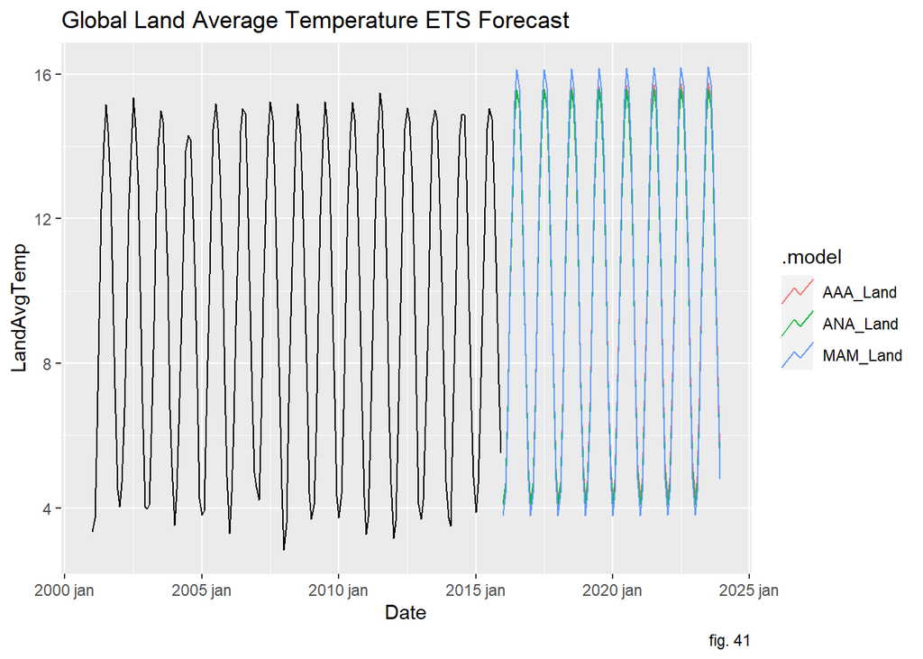

```r
fit_global_land %>%
  forecast(h = "8 years") %>%
  autoplot(filter(global_temp, year(Date)>2000),level = NULL) + labs(title = "Global Land Average Temperature ETS Forecast", caption = "fig. 41")
```

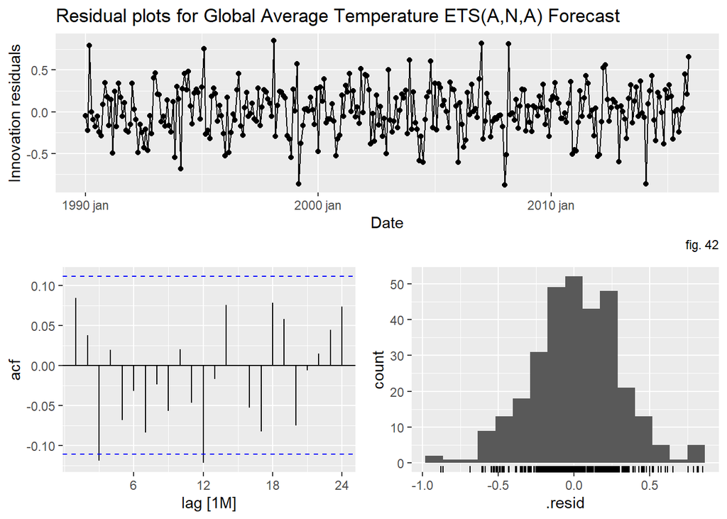

```r
fit_ANA %>%
  gg_tsresiduals() + labs(title = "Residual plots for Global Average Temperature ETS(A,N,A) Forecast", caption = "fig. 42")
```

By looking at the distribution plot of the residuals, it is possible to visualize that the residuals do tend to cluster around zero. Besides that, only 2 out of 24 lags in the ACF are barely significant. This means that the residuals do seem to be white noise. Which leads to the conclusion that the residuals are normal and uncorrelated. Therefore, the forecasts should also follow a normal distribution. This indicates that using an exponential smoothing method that is comprised of an additive error with a null trend and additive seasonal component would yield fairly decent forecasts.

### Continents’ Land Average Temperature

Similarly to what was done for global land average temperature, this time around, exponential smoothing methods will be applied to forecast average temperatures for each continent available in the data set that is being studied.

```r
land_continents <-
  GlobalCountryTemp %>%
  filter(Country %in% c("North America", "South America", "Europe", "Asia", "Oceania", "Africa")) %>%
  filter(year(Date)>=1990)

fit_continents <- land_continents %>%
  model(
    ANA_Continents = ETS(LandAvgTemp)
  )

fit_continents %>% report()
```

```
## # A tibble: 6 x 10
##   Country       .model       sigma2 log_lik   AIC  AICc   BIC    MSE  AMSE   MAE
##   <chr>         <chr>         <dbl>   <dbl> <dbl> <dbl> <dbl>  <dbl> <dbl> <dbl>
## 1 Africa        ANA_Contine~  0.105   -477.  984.  986. 1039. 0.0997 0.118 0.242
## 2 Asia          ANA_Contine~  0.618   -730. 1489. 1491. 1544. 0.588  0.597 0.538
## 3 Europe        ANA_Contine~  1.46    -853. 1735. 1737. 1790. 1.39   1.39  0.865
## 4 North America ANA_Contine~  0.662   -739. 1509. 1511. 1564. 0.629  0.680 0.612
## 5 Oceania       ANA_Contine~  0.450   -685. 1399. 1401. 1454. 0.428  0.466 0.497
## 6 South America ANA_Contine~  0.125   -502. 1035. 1037. 1090. 0.119  0.129 0.250
```

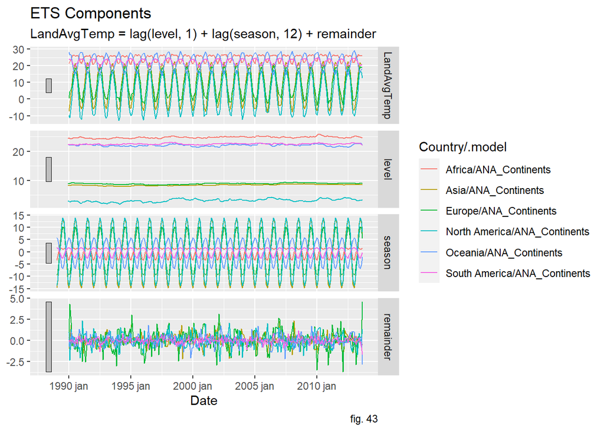

```r
fit_continents %>%
  components() %>%
  autoplot() + labs(title = "ETS Components", caption = "fig. 43")
```

The exponential smoothing method that minimizes the AIC, Corrected AIC and BIC for all the six continents available in the data set is the ANA Exponential Smoothing Method. This was also the best exponential smoothing method for the global land average temperature time series that we have previously seen.

It is important to highlight that the level and seasonality ETS components differ drastically from continent to continent. Africa, South America and Oceania have a level above 20. Whereas Europe, Asia and North America have a level below 10. This is obviously related with the fact that temperatures in the latter three continents are significantly lower than in the former three. Besides that, there seems to be a much higher seasonal variation in Europe, Asia and North America than in Africa, Oceania and South America.

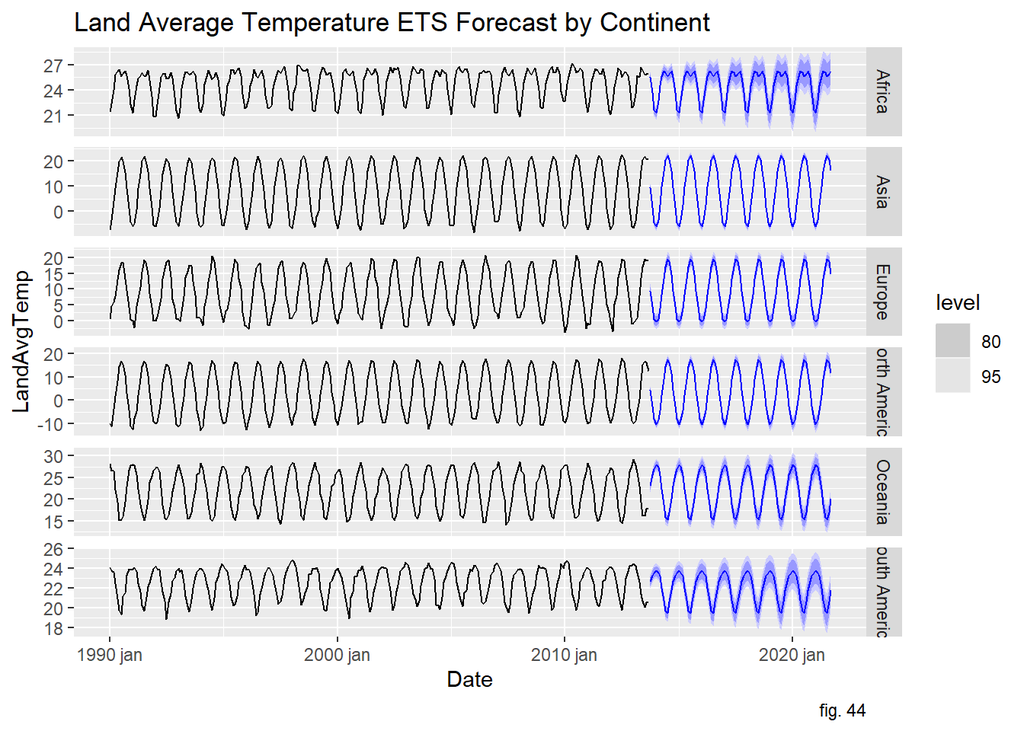

```r
fit_continents %>%
  forecast(h = "8 years") %>%
  autoplot(land_continents) + facet_grid(Country~., scales = "free_y", shrink = T)  + labs(title = "Land Average Temperature ETS Forecast by Continent", caption = "fig. 44")
```